# ④（コレクション）

# Lesson6

### 構文（タプルの作成）

```
<タプル名> = (<値1>, <値2>, …)
```

### 構文（タプルの値の取得）

```
<タプル名>[<インデックス>]
```

### 構文（ディクショナリの作成）

```
<ディクショナリ名> = {<キー>:<値>, <キー>:<値>,…}
```

### 構文（ディクショナリの要素の取得）

```
<ディクショナリ名>[<キー>]
```

### Sample1.py

```python
sale = {"東京":80, "名古屋":60, "京都":22, "大阪":50, "福岡":75}
print("現在のデータは", sale, "です。")

k = input("どの支店のデータを表示しますか？")
print(k, "のデータは", sale[k], "です。")
```

```
現在のデータは {'東京': 80, '名古屋': 60, '京都': 22, '大阪': 50, '福岡': 75} です。
どの支店のデータを表示しますか？東京
東京 のデータは 80 です。
```

### Sample2.py

```python
sale = {"東京":80, "名古屋":60, "京都":22, "大阪":50, "福岡":75}
print("現在のデータは", sale, "です。")

k = input("どのキーのデータを表示しますか？")
if k in sale:
    print(k, "のデータは", sale[k], "です。")
else:
    print(k, "のデータはみつかりませんでした。")
```

```
現在のデータは {'東京': 80, '名古屋': 60, '京都': 22, '大阪': 50, '福岡': 75} です。
どのキーのデータを表示しますか？東京
東京 のデータは 80 です。
```

### 構文（ディクショナリの要素の変更）

```
<ディクショナリ名>[<キー>] = <値>
```

### 構文（ディクショナリの要素の追加）

```
<ディクショナリ名>[<キー>] = <値>
```

### 構文（ディクショナリの要素の削除）

```
del <ディクショナリ名>[<キー>]
```

### Sample3.py

```python
sale = {"東京":80, "名古屋":60, "京都":22, "大阪":50, "福岡":75}
print("現在のデータは", sale, "です。")

k = input("追加するキーを入力してください。")
if k in sale:
    print(k, "のデータはすでに存在しています。")
else:
    d = int(input("追加するデータを入力してください。"))
    sale[k] = d
    print(k, "のデータとして", sale[k], "を追加しました。")
print("現在のデータは", sale, "です。")

k = input("どのキーのデータを変更しますか？")
if k in sale:
    print(k, "のデータは", sale[k], "です。")
    d = int(input("データを入力してください。"))
    sale[k] = d
    print(k, "のデータは", sale[k], "に変更されました。")
else:
    print(k, "のデータはみつかりませんでした。")
print("現在のデータは", sale, "です。")

k = input("どのキーのデータを削除しますか？")
if k in sale:
    print(k, "のデータは", sale[k], "です。")
    del sale[k]
    print("データを削除しました。")
else:
    print(k, "のデータはみつかりませんでした。")
print("現在のデータは", sale, "です。")
```

### Sample4.py

```python
sale = {"東京":80, "名古屋":60, "京都":22, "大阪":50, "福岡":75}
print("現在のデータは", sale, "です。")

print("キーを表示します。")
for k in sale.keys():
    print(k, end="\t")
print()

print("値を表示します。")
for v in sale.values():
    print(v, end="\t")
print()

print("キーと値を表示します。")
for i in sale.items():
    print(i, end="")
print()
```

### 構文（ディクショナリの更新）

```
<ディクショナリ名>.update(<追加するディクショナリ名>)
```

### Sample5.py

```python
sale1 = {"東京":80, "名古屋":60, "京都":22}
sale2 = {"京都":100, "大阪":50, "福岡":75}

print("1のデータは", sale1, "です。")
print("2のデータは", sale2, "です。")

print("1を2で更新します。")

sale1.update(sale2)

print("1のデータは", sale1, "です。")
```

### 構文（セットの作成

```
<セット名> = {<値>,<値>,…}
<セット名> = set([<値>,<値>,…])
<セット名> = set()
```

### 構文（セット要素の追加・削除）

```
<セット名>.add(<値>)
<セット名>.remove(<値>)
```

### Sample6.py

```python
city = {"東京", "名古屋", "京都", "大阪", "福岡"}
print("現在のデータは", city, "です。")

d = input("追加するデータを入力してください。")
if d in city:
    print(d, "はすでに存在しています。")
else:
    city.add(d)
    print(d, "を追加しました。")
print("現在のデータは", city, "です。")

d = input("削除するデータを入力してください。")
if d in city:
    city.remove(d)
    print(d, "を削除しました。")
else:
    print(d, "はみつかりませんでした。")
print("現在のデータは", city, "です。")
```

## 集合演算

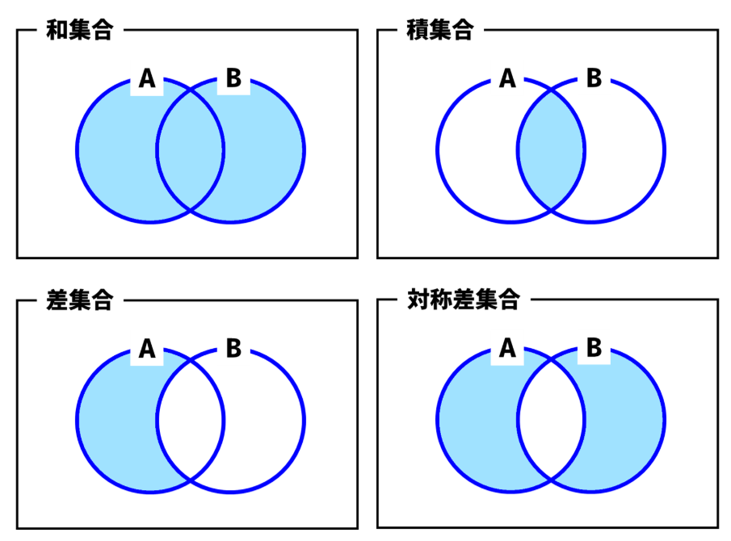

### Sample7.py

```python
cityA = {"東京", "名古屋", "京都", "大阪"}
cityB = {"京都", "大阪", "福岡"}

print("Aの都市名は", cityA, "です。")
print("Bの都市名は", cityB, "です。")

print("共通するデータは", cityA & cityB, "です。")
print("Aのみのデータは",  cityA - cityB, "です。")
print("Bのみのデータは",  cityB - cityA, "です。")
print("すべてのデータは", cityA | cityB, "です。")
```

# ほげ要望(^ω^)

教科書 【レッスンのまとめ】  
・lesson6  
練習をやってくれたら喜びます

# エクストラほげ問題④

## 高校数学Ⅱ 整式の積分

## 不定積分の計算・性質・公式

人工知能（AI）を学ぶ上で必須な数学の知識を問うような問題を出します。  
最低限の内容ばかり問うのでわからない人は焦った方がいいと思います（ほげおくん調べ）

### もんだいだよん(^ω^)

次の不定積分を求めなさい

①$\int (5x^3-4x^2+6x-8) dx$

②$\int (x^2-3x) dx + 2\int (x^2+2)dx$

③$\int (3x-1)(2x+5) dx$

## エクストラぽむぽむ問題

# ほげ問題に悩ませているあなた、ぜひぽむぽむ問題を解いてみよう。

### １．辞書型リストを使ってレジを改良しよう

> 二つ前のぽむぽむ問題をリメイクするよ。  
> もしやってないひとは、そこからコードをもってきてやると書き換えるところが少ないから便利！

前のレジシステムは一律値段が同じでした。今回は辞書型リストを使って、  
それぞれの商品に異なった値段をつけてみよう。  
※相変わらず例はいちごみるくばななみるくめろんみるくです。

#### 以下実行結果

```python
# 前回のぽむぽむ問題を参考に、自分で書き換えて作成してね
```

[output not shown]

## ２．在庫管理をしよう

> この内容は教科書に書いている部分が大半なので全部自分で組んでみよう。  
> めざすのは動くだけでなくシンプルで、わかりやすいソースコード！

上で作った商品と値段のリストから、インデックス０番目のモノを削除 新しく商品を値段をきめて追加してみよう。

#### 以下実行結果

=== Menu ====  
いちごみるく 300 円  
ばななみるく 200 円  
めろんみるく 250 円  
削除する商品を入力いちごみるく  
いちごみるく を削除しました  
リストの中身は {'ばななみるく': 200, 'めろんみるく': 250} です  
追加する商品を入力れもんみるく  
値段を入力400  
{'ばななみるく': 200, 'めろんみるく': 250, 'れもんみるく': 400}

```python
#★の部分をかいて完成させてね
item = #★
print("=== Menu ====")
for i, p in #★
    print(i,p,"円")

delete = input("削除する商品を入力")

#★　削除するコード
print(delete,"を削除しました")
print("リストの中身は",item,"です")

addName = input("追加する商品を入力")
addPrice = int(input("値段を入力"))
item#★
print(item)
```

[output not shown]

# エクストラがんばれもんだい

コレクションだけやるのわからんから関数やっちゃう

```python
#下の関数二つを動かし、「ab」と表示してね
def a():
    print("a",end="")

def b():
    print("b")

#下に書いて
```

```python
#引数を正しくして、「123」と表示されるようにしてね
a=1
b=2
c=3
def func(d,e,f):
    print(f,d,e)
#変えるとこ↓
func(c,a,b)
```

```
2 3 1
```

```python
'''whileと関数funcを使用して「0
                            01
                            012
                            ...
                            ...
                            0123456789」と表示してね'''
num=0
s=""
def func():
    global num
    global s
    s+=str(num)
    print(s)
    num+=1

while
```